# Week 4 Lab: Sentiment Analysis II

This .Rmd available here: https://raw.githubusercontent.com/MaRo406/EDS_231-text-sentiment/main/topic_4.Rmd

### IPCC Report Twitter

```r
library(quanteda)
#devtools::install_github("quanteda/quanteda.sentiment") #not available currently through CRAN
library(quanteda.sentiment)
library(quanteda.textstats)
library(tidyverse)
library(tidytext)
library(lubridate)
library(wordcloud) #visualization of common words in the data set
library(reshape2)
library(sentimentr)
library(patchwork)
```

Load the data and sentiment lexicons

```r
raw_tweets <- read.csv("https://raw.githubusercontent.com/MaRo406/EDS_231-text-sentiment/main/dat/IPCC_tweets_April1-10_sample.csv", header=TRUE) # get raw data

dat<- raw_tweets[,c(4,6, 10, 11)] # Extract Date and Title fields

#load sentiment lexicons
bing_sent <- get_sentiments('bing')
nrc_sent <- get_sentiments('nrc')
```

### 1. Think about how to further clean a twitter data set. Let’s assume that the mentions of twitter accounts is not useful to us. Remove them from the text field of the tweets tibble.

```r
tweets <- tibble(text = dat$Title,
                  id = seq(1:length(dat$Title)),
                 date = as.Date(dat$Date,
                                '%m/%d/%y'),
                 sentiment = dat$Sentiment,
                 emotion = dat$Emotion) %>%
  mutate(text = str_replace(string = text,
                            pattern = "http.*[:space:]",
                            replacement = ""),
         text = str_replace(string = text,
                            pattern = "http.*$",
                            replacement = ""),
         text = str_replace(string = text,
                            pattern = "@.*[:space:]",
                            replacement = ""),
         text = str_replace(string = text,
                            pattern = "@.*$",
                            replacement = ""),
         text = str_to_lower(text))

tweets$text <- iconv(tweets$text,
                     "latin1",
                     "ASCII",
                     sub="")
```

### 2. Compare the ten most common terms in the tweets per day. Do you notice anything interesting?

Make dataframe with each word in different row, remove all stop words, add in the `bing` sentiment, and a numerical sentiment score.

```r
#tokenize tweets to individual words
words <- tweets %>%
  select(id, date, text) %>%
  unnest_tokens(output = word, input = text, token = "words") %>%
  anti_join(stop_words, by = "word") %>%
  left_join(bing_sent, by = "word") %>%
  left_join(
    tribble(
      ~sentiment, ~sent_score,
      "positive", 1,
      "negative", -1),
    by = "sentiment")
```

Make a slice of the top ten words of each day then make a plot.

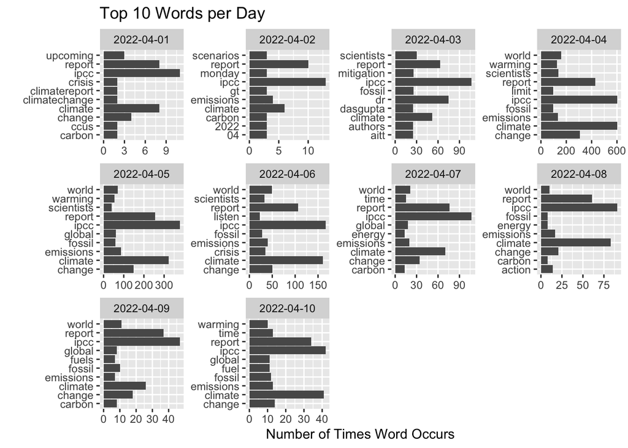

```r
ten_words <- words %>%
  group_by(date, word) %>%
  summarise(count = n()) %>%
  group_by(date) %>%
  slice_max(count,
            n = 10,
            with_ties = FALSE) %>%
  ggplot(aes(x = count,
             y = word)) +
  geom_col() +
  facet_wrap(~date, scales = "free") +
  guides(fill = "none") +
  labs(x = "Number of Times Word Occurs",
       y = "",
       title = "Top 10 Words per Day")
ten_words
```

The day the report is released and for a couple of days after there is a great increase in the number of mentions of IPCC because the counts are much higher for all words. IPCC, report, and climate is high throughout the dates but this is expected.

### 3. Adjust the wordcloud in the “wordcloud” chunk by coloring the positive and negative words so they are identifiable.

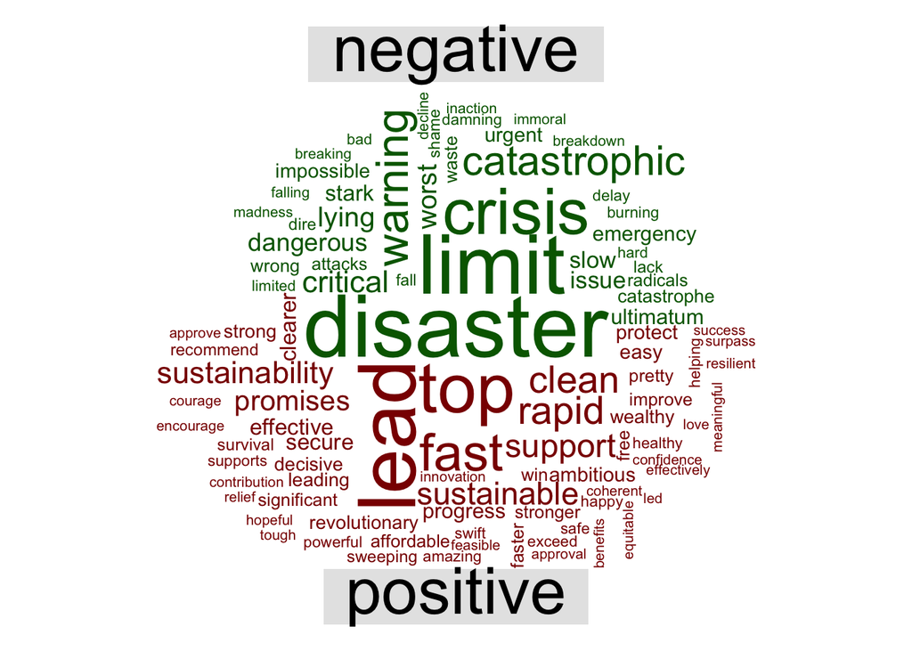

```r
words %>%
  inner_join(get_sentiments("bing")) %>%
  count(word, sentiment, sort = TRUE) %>%
  acast(word ~ sentiment, value.var = "n", fill = 0) %>%
  comparison.cloud(colors = c("darkgreen", "red4"),
                   max.words = 100)
```

### 4. Let’s say we are interested in the most prominent entities in the Twitter discussion. Which are the top 10 most tagged accounts in the data set.

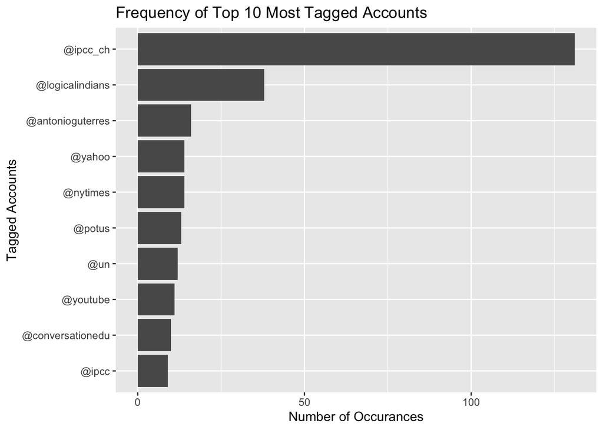

```r
corpus <- corpus(dat$Title) #enter quanteda

tag_tweets <- tokens(corpus, remove_punct = TRUE) %>%
  tokens_keep(pattern = "@*") %>%
  dfm() %>%
  textstat_frequency(n = 10) %>%
  ggplot(aes(x = frequency,
           y = reorder(feature, frequency))) +
  geom_col() +
  labs(x = "Number of Occurances",
       y = "Tagged Accounts",
       title = "Frequency of Top 10 Most Tagged Accounts")

tag_tweets
```

### 5. The Twitter data download comes with a variable called “Sentiment” that must be calculated by Brandwatch. Use your own method to assign each tweet a polarity score (Positive, Negative, Neutral) and compare your classification to Brandwatch’s (hint: you’ll need to revisit the “raw_tweets” data frame).

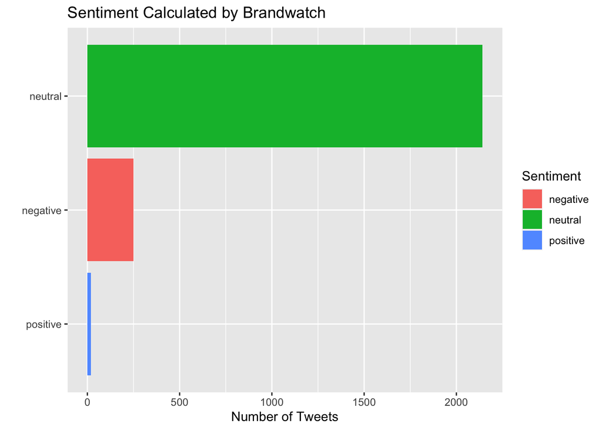

```r
sentimentr_calc <- get_sentences(dat$Title) %>%
  sentiment() %>%
  group_by(element_id) %>%
  summarize(sentiment_score = mean(sentiment)) %>%
  mutate(sentiment = case_when(sentiment_score < 0 ~ "negative",
                               sentiment_score == 0 ~ "neutral",
                               sentiment_score > 0 ~ "positive")) %>%
  group_by(sentiment) %>%
  summarize(count = n())%>%
  ggplot(aes(x = count,
             y = reorder(sentiment, count),
             fill = sentiment)) +
  geom_col() +
  labs(x = "Number of Tweets",
       y = "",
       title = "Sentiment Calculated with `Sentimentr` Package")

brandwatch_calc <- dat %>%
  filter(Sentiment %in% c("positive", "negative", "neutral")) %>%
  group_by(Sentiment) %>%
  summarize(count = n()) %>%
  ggplot(aes(x = count,
             y = reorder(Sentiment, count),
             fill = Sentiment)) +
  geom_col() +
  labs(x = "Number of Tweets",
       y = "",
       title = "Sentiment Calculated by Brandwatch")


brandwatch_calc
```

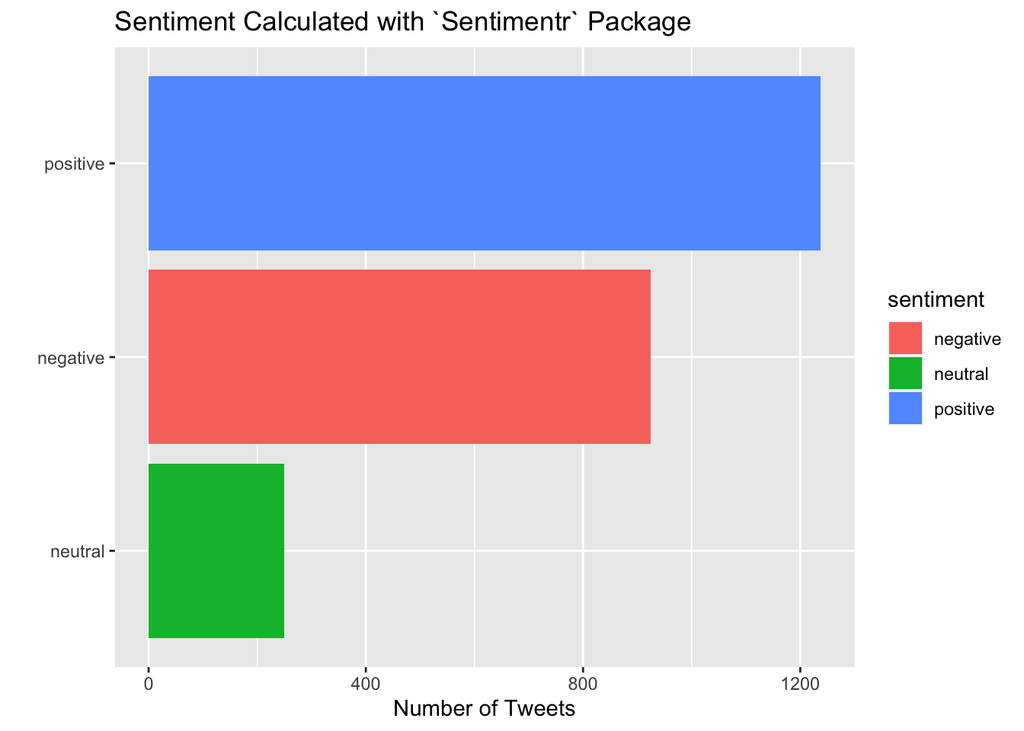

```r
sentimentr_calc
```

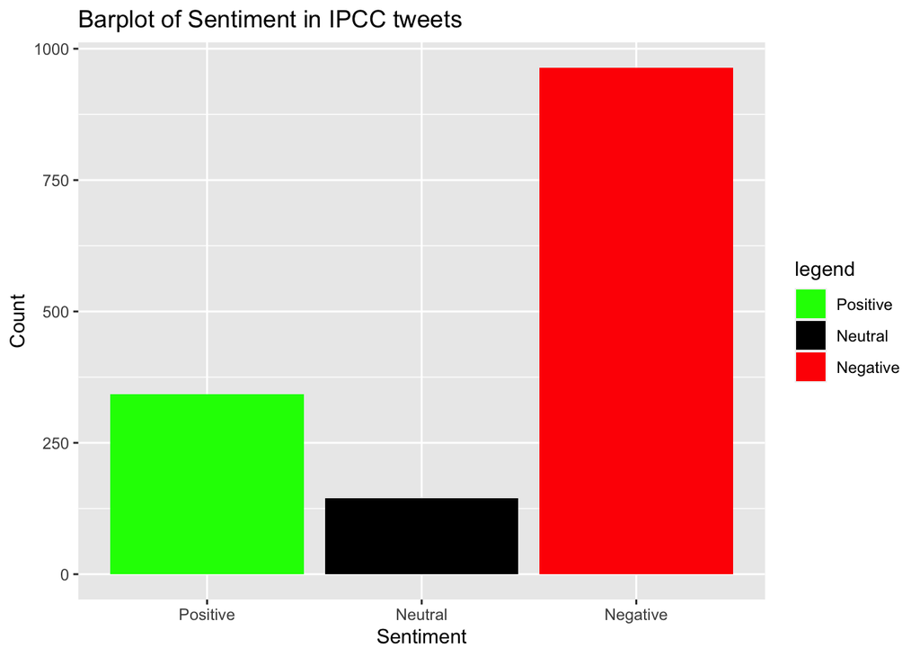

```r
#take average sentiment score by tweet
tweets_sent <- tweets %>%
  left_join(
    words %>%
      group_by(id) %>%
      summarize(
        sent_score = mean(sent_score, na.rm = T)),
    by = "id")

neutral <- length(which(tweets_sent$sent_score == 0))
positive <- length(which(tweets_sent$sent_score > 0))
negative <- length(which(tweets_sent$sent_score < 0))

Sentiment <- c("Positive","Neutral","Negative")
Count <- c(positive,neutral,negative)
output <- data.frame(Sentiment,Count)
output$Sentiment<-factor(output$Sentiment,levels=Sentiment)
ggplot(output, aes(x=Sentiment,y=Count))+
  geom_bar(stat = "identity", aes(fill = Sentiment))+
  scale_fill_manual("legend", values = c("Positive" = "green", "Neutral" = "black", "Negative" = "red"))+
  ggtitle("Barplot of Sentiment in IPCC tweets")
```

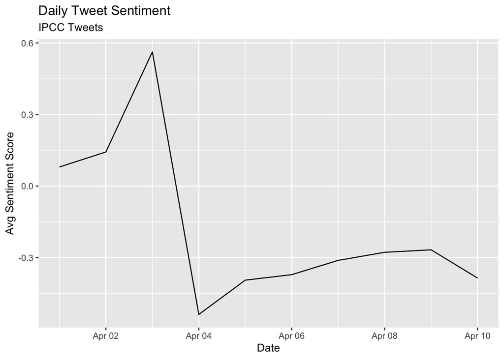

```r
# tally sentiment score per day
daily_sent <- tweets_sent %>%
  group_by(date) %>%
  summarize(sent_score = mean(sent_score, na.rm = T))

daily_sent %>%
  ggplot( aes(x = date, y = sent_score)) +
  geom_line() +
    labs(x = "Date",
    y = "Avg Sentiment Score",
    title = "Daily Tweet Sentiment",
    subtitle = "IPCC Tweets")
```

Now let’s try a new type of text visualization: the wordcloud.

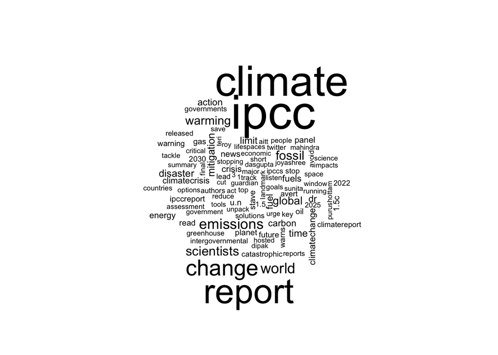

```r
words %>%
   anti_join(stop_words) %>%
   count(word) %>%
   with(wordcloud(word, n, max.words = 100))
```

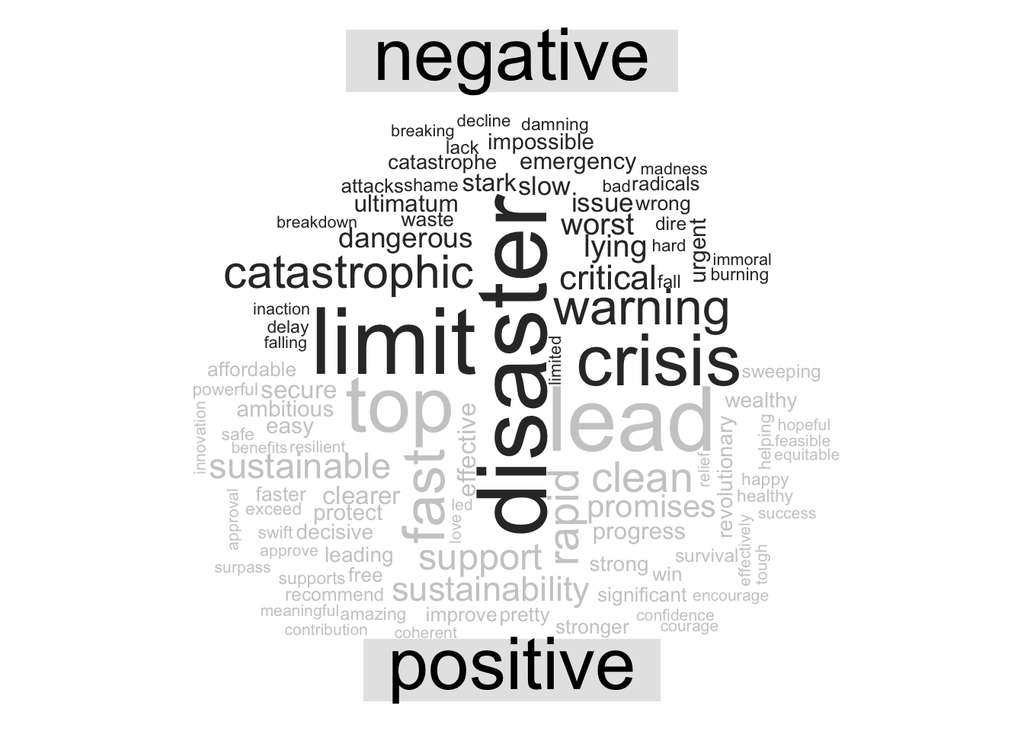

```r
words %>%
  inner_join(get_sentiments("bing")) %>%
  count(word, sentiment, sort = TRUE) %>%
  acast(word ~ sentiment, value.var = "n", fill = 0) %>%
  comparison.cloud(colors = c("gray20", "gray80"),
                   max.words = 100)
```

#### The quanteda package

quanteda is a package (actually a family of packages) full of tools for conducting text analysis. quanteda.sentiment (not yet on CRAN, download from github) is the quanteda modular package for conducting sentiment analysis.

quanteda has its own built in functions for cleaning text data. Let’s take a look at some. First we have to clean the messy tweet data:

```r
corpus <- corpus(dat$Title) #enter quanteda
summary(corpus)
```

```
## Corpus consisting of 2411 documents, showing 100 documents:
##
##     Text Types Tokens Sentences
##    text1    43     53         2
##    text2    37     42         2
##    text3    31     32         2
##    text4    42     49         3
##    text5    21     25         2
##    text6    30     33         1
##    text7    10     12         1
##    text8    40     42         2
##    text9    16     17         1
##   text10    36     42         2
##   text11    16     16         1
##   text12    34     44         6
##   text13    35     46         3
##   text14    46     52         2
##   text15    42     51         1
##   text16     7      7         1
##   text17    42     48         2
##   text18    17     17         2
##   text19    43     60         1
##   text20    27     34         3
##   text21    40     43         3
##   text22    44     50         3
##   text23    28     30         2
##   text24    35     38         3
##   text25    36     41         3
##   text26    37     43         4
##   text27    21     23         1
##   text28    29     31         1
##   text29    12     13         1
##   text30    45     47         2
##   text31    38     42         1
##   text32    31     36         1
##   text33    14     14         1
##   text34    41     49         1
##   text35     7      7         1
##   text36    44     54         2
##   text37    26     28         1
```

[output cut: 48 more lines]

```
##   text86    39     43         2
##   text87    13     13         1
##   text88    13     13         1
##   text89    38     46         1
##   text90    38     46         1
##   text91    38     46         1
##   text92    40     43         1
##   text93    11     11         1
##   text94    41     49         1
##   text95    38     46         1
##   text96    15     15         1
##   text97    29     31         1
##   text98    11     11         1
##   text99    13     13         1
##  text100    38     46         1
```

```r
tokens <- tokens(corpus) #tokenize the text so each doc (page, in this case) is a list of tokens (words)

#examine the uncleaned version
tokens
```

```
## Tokens consisting of 2,411 documents.
## text1 :
##  [1] "thank"       "you"         ","           "followers"   ","
##  [6] "for"         "the"         "great"       "photo"       "suggestions"
## [11] "for"         "our"
## [ ... and 41 more ]
##
## text2 :
##  [1] "Greenpeace" ":"          "The"        "real"       "solution"
##  [6] "to"         "the"        "climate"    "crisis"     "will"
## [11] "require"    "a"
## [ ... and 30 more ]
##
## text3 :
##  [1] "Governments"    "have"           "a"              "responsibility"
##  [5] "to"             "ensure"         "that"           "#IPCCReport"
##  [9] "is"             "grounded"       "in"             "rapid"
## [ ... and 20 more ]
##
## text4 :
##  [1] "Next"      "week"      ","         "the"       "IPCC"      "will"
##  [7] "publish"   "a"         "new"       "report"    "detailing" "their"
## [ ... and 37 more ]
##
## text5 :
##  [1] "Live"       "stream"     "of"         "virtual"    "IPCC"
##  [6] "press"      "conference" "releasing"  "the"        "report"
## [11] "on"         "mitigation"
## [ ... and 13 more ]
##
## text6 :
##  [1] "Attention"   "journalists" ":"           "The"         "deadline"
##  [6] "for"         "embargoed"   "materials"   "for"         "the"
## [11] "upcoming"    "@IPCC_CH"
## [ ... and 21 more ]
##
## [ reached max_ndoc ... 2,405 more documents ]
```

```r
#clean it up
tokens <- tokens(tokens, remove_punct = TRUE,
                      remove_numbers = TRUE)

tokens <- tokens_select(tokens, stopwords('english'),selection='remove') #stopwords lexicon built in to quanteda

#tokens <- tokens_wordstem(tokens) #stem words down to their base form for comparisons across tense and quantity
# since we are doing visual analysis we are leaving this out but if we were doing rigorous analysis we would want to do it.

tokens <- tokens_tolower(tokens)
```

We can use the kwic function (keywords-in-context) to briefly examine the context in which certain words or patterns appear.

```r
head(kwic(tokens, pattern = "climate", window = 3))
```

```
## Keyword-in-context with 6 matches.
##    [text2, 4]    greenpeace real solution | climate |
##   [text2, 17]        upcoming#ipcc report | climate |
##   [text5, 10] releasing report mitigation | climate |
##    [text6, 9]     upcoming@ipcc_ch report | climate |
##    [text7, 4]         ipcc report physics | climate |
##  [text10, 10]          much lose critical | climate |
##
##  crisis require rapid
##  solutions set publication
##  change a.m gmt
##  mitigation extended today
##  change https://t.co/xnxp3fup2a
##  water risks grow
```

```r
head(kwic(tokens, pattern = phrase("climate change"), window = 3))
```

```
## Keyword-in-context with 6 matches.
##   [text5, 10:11] releasing report mitigation | climate change |
##     [text7, 4:5]         ipcc report physics | climate change |
##  [text14, 15:16]         avert worst effects | climate change |
##  [text15, 10:11]   s#climatereport emissions | climate change |
##    [text20, 1:2]                             | climate change |
##    [text24, 6:7]      report revealed threat | climate change |
##
##  a.m gmt o
##  https://t.co/xnxp3fup2a
##  anyone think revolution
##  meenakshi raman@sahabatalammsia
##  want learn 100s
##  team weighed findings
```

```r
hash_tweets <- tokens(corpus, remove_punct = TRUE) %>%
               tokens_keep(pattern = "#*")

dfm_hash<- dfm(hash_tweets)

tstat_freq <- textstat_frequency(dfm_hash, n = 100)
head(tstat_freq, 10)
```

```
##              feature frequency rank docfreq group
## 1              #ipcc       464    1     460   all
## 2     #climatechange       137    2     135   all
## 3     #climatecrisis       118    3     117   all
## 4     #climatereport        97    4      97   all
## 5        #ipccreport        87    5      87   all
## 6           #climate        68    6      67   all
## 7  #climateemergency        45    7      45   all
## 8     #climateaction        44    8      44   all
## 9     #globalwarming        24    9      24   all
## 10 #climateactionnow        23   10      23   all
```

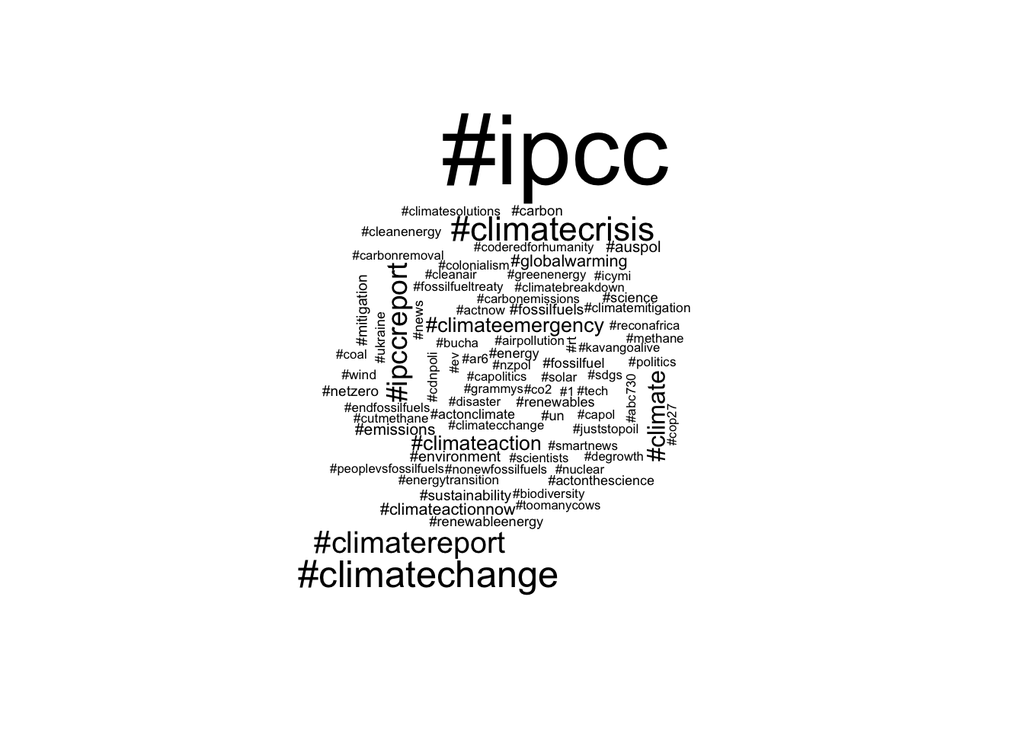

```r
#tidytext gives us tools to convert to tidy from non-tidy formats
hash_tib<- tidy(dfm_hash)

hash_tib %>%
   count(term) %>%
   with(wordcloud(term, n, max.words = 100))
```

```r
# words %>%
#   inner_join(get_sentiments("bing")) %>%
#   count(word, sentiment, sort = TRUE) %>%
#   acast(word ~ sentiment, value.var = "n", fill = 0) %>%
#   comparison.cloud(colors = c("gray20", "gray80"),
#                    max.words = 100)
```

Create the sparse matrix representation known as the document-feature matrix. quanteda’s textstat_polarity function has multiple ways to combine polarity to a single score. The sent_logit value to fun argument is the log of (pos/neg) counts.

```r
dfm <- dfm(tokens)

topfeatures(dfm, 12)
```

```
##    climate       ipcc     report     change        now      #ipcc      world
##       1396       1243       1225        651        505        464        346
##  emissions      never        new     latest scientists
##        333        291        279        279        274
```

```r
dfm.sentiment <- dfm_lookup(dfm, dictionary = data_dictionary_LSD2015)

head(textstat_polarity(tokens, data_dictionary_LSD2015, fun = sent_logit))
```

```
##   doc_id sentiment
## 1  text1  2.197225
## 2  text2 -1.098612
## 3  text3  1.945910
## 4  text4  0.000000
## 5  text5  1.098612
## 6  text6  1.098612
```

### Assignment

You will use the tweet data from class today for each part of the following assignment.